# Module 2: Chi-Square testing and ANOVA

Rhea Thoppil, ALY6015 Intermediate Analytics

2024-01-21

# Introduction:

This project delves into the realm of statistical analysis within the field of biostatistics and business analytics, employing chi-square and ANOVA testing to unearth patterns, relationships, and disparities within various datasets. Through the application of these statistical tests, we aim to discern whether observed frequencies align with expected distributions. Each task is approached with a structured methodology: stating hypotheses, computing critical and test values, making decisive conclusions, and summarizing the findings.

# Task 1 (Section 11-1 6. Blood Types)

A medical researcher wishes to see if hospital patients in a large hospital have the same blood type distribution as those in the general population. The distribution for the general population is as follows:

- type A = 20%
- type B = 28%
- type O = 36%
- type AB = 16%

He selects a random sample of 50 patients and finds the following:

- 12 have type A blood
- 8 have type B
- 24 have type O
- 6 have type AB blood

At α = 0.10, can it be concluded that the distribution is the same as that of the general population?

# Solution

## $\chi^2$ Test

Forming of vectors of $expected$ probabilities and $observed$ frequencies, then we run the test afterwards.

```r
# Observed frequencies in the hospital sample
observed1 <- c(12, 8, 24, 6)

# Expected frequencies based on the general population distribution
expected1 <- c(0.20 * 50, 0.28 * 50, 0.36 * 50, 0.16 * 50)

# alpha at 0.10
alpha1 <- 0.10
```

### Step 1. Stating the hypotheses and identify the claim

The hypothesis for the above will be as follow:

**Null Hypothesis**: The distribution of blood types in hospital patients is the same as that of the general population.

**Alternative Hypothesis**: The distribution of blood types in hospital patients is different from that of the general population.

### Step 2. Finding the critical value

When using the p-value for analysis, no critical value is needed.

### Step 3. Computing the test results

```r
# Chi-square test
chi_square1 <- chisq.test(observed1, p = expected1 / sum(expected1))

# Print the test results
print(chi_square1)
```

```
##
##  Chi-squared test for given probabilities
##
## data:  observed1
## X-squared = 5.4714, df = 3, p-value = 0.1404
```

### Step 4 - Analyzing the results

*Hypothesis Rule:* If the p-value is less than alpha, we must reject the Null Hypothesis. If the p-value is greater than alpha, we do not have enough evidence to reject the Null Hypothesis.

**Interpretation:**

- If the p-value is less than the significance level (α = 0.10), then we would reject the null hypothesis. In this case, the p-value is 0.1404, which is greater than alpha = 0.10.

### Step 5 - Conclusion

Therefore, based on the p-value of 0.1404, we would fail to reject the null hypothesis. Hence, there is not enough evidence to conclude that the distribution of blood types in hospital patients is different from that of the general population at a significance level of 0.10.

# Task 2 (Section 11-1. 8. On-Time Performance by Airlines)

According to the Bureau of Transportation Statistics, on-time performance by the airlines is described as follows:

| Action | **% of Time** |
| --- | --- |
| On-time | 70.8 |
| National Aviation System delay | 8.2 |
| Aircraft arriving late | 9.0 |
| Other (because of weather and other conditions) | 12.0 |

Records of 200 randomly selected flights for a major airline company showed that

- 125 planes were on time
- 40 were delayed because of weather
- 10 because of a National Aviation System delay
- 25 because of arriving late

At α = 0.05, do these results differ from the government’s statistics?

*Source:* www.transtats.bts.gov

### Solution

## $\chi^2$ Test

Forming of vectors of $expected$ probabilities and $observed$ frequencies, then we run the test afterwards.

```r
# Observed frequencies
observed2 <- c(125, 10, 40, 200 - (125 + 10 + 40))

# Expected frequencies based on the given percentages
expected2 <- c(0.708 * 200, 0.082 * 200, 0.090 * 200, 0.120 * 200)
```

### Step 1. Stating the hypotheses and identify the claim

The hypothesis for the above will be as follow:

**Null Hypothesis**: The distribution of on-time performance categories for the airline is consistent with the expected distribution provided by the Bureau of Transportation Statistics.

**Alternative Hypothesis**: There is a significant difference in the distribution of on-time performance categories for the airline compared to the expected distribution provided by the Bureau of Transportation Statistics.

### Step 2. Finding the critical value

When using the p-value for analysis, no critical value is needed.

### Step 3. Computing the test results

```r
# to set the results to numerical digits
options(scipen = 100, digits = 10)

# Chi-square test
chi_square2 <- chisq.test(observed2, p = expected2 / sum(expected2))

# Print the test results
print(chi_square2)
```

```
##
##  Chi-squared test for given probabilities
##
## data:  observed2
## X-squared = 31.374162, df = 3, p-value = 0.0000007090023
```

```r
options(scipen = 100, digits = 10)
```

### Step 4 - Analyzing the results

*Hypothesis Rule:* If the p-value is less than alpha, we must reject the Null Hypothesis. If the p-value is greater than alpha, we do not have enough evidence to reject the Null Hypothesis.

**Interpretation:**

- If the p-value is less than the significance level (α = 0.05), we would reject the null hypothesis. In this case, the p-value is 0.0000007090023, which is far less than alpha = 0.05.

### Step 5 - Conclusion

**Given that the p-value is quite low, we would reject the null hypothesis.** There is strong evidence to conclude that there is a significant difference in the distribution of on-time performance categories for the airline compared to the expected distribution provided by the Bureau of Transportation Statistics at a significance level of 0.05.

# Task 3 (Section 11-2.8. Ethnicity and Movie Admissions)

Are movie admissions related to ethnicity? A 2014 study indicated the following numbers of admissions (in thousands) for two different years. At the 0.05 significance level, can it be concluded that movie attendance by year depended on ethnicity?

|  | **Caucasian** | **Hispanic** | **African American** | **Other** |
| --- | --- | --- | --- | --- |
| 2013 | 724 | 335 | 174 | 107 |
| 2014 | 370 | 292 | 152 | 140 |

*Source: MPAA Study*.

# Solution

## $\chi^2$ Test

```r
# Create vectors for the observed frequencies
observed2013 <- c(724, 335, 174, 107)
observed2014 <- c(370, 292, 152, 140)

# Combine the vectors into a matrix
movie_matrix <- rbind(observed2013, observed2014)
```

### Step 1. Stating the hypotheses and identify the claim

**Null Hypothesis**: There is no association between movie attendance and ethnicity. In other words, movie attendance is independent of ethnicity.

**Alternative Hypothesis**: There is a significant association between movie attendance and ethnicity. Movie attendance is not independent of ethnicity.

### Step 2. Finding the critical value

When using the p-value for analysis, no critical value is needed.

### Step 3. Computing the test results

```r
# Perform chi-square test for independence
chi_square3 <- chisq.test(movie_matrix)

# Print the test results
print(chi_square3)
```

```
##
##  Pearson's Chi-squared test
##
## data:  movie_matrix
## X-squared = 60.143525, df = 3, p-value = 0.0000000000005477507
```

### Step 4 - Analyzing the results

*Hypothesis Rule:* If the p-value is less than alpha, we must reject the Null Hypothesis. If the p-value is greater than alpha, we do not have enough evidence to reject the Null Hypothesis.

**Interpretation:**

- If the p-value is less than the significance level (α = 0.05), then we would reject the null hypothesis. Here, the p-value is 0.0000000000005477507, which is less than alpha = 0.05.

### Step 5 - Conclusion

A matrix was constructed as part of the process because the chi-square test for independence required it. The layout of a contingency table is useful for arranging and examining the data when dealing with two variables.

Therefore, **given that the p-value is quite low, we would reject the null hypothesis**. There is strong evidence to conclude that movie attendance depends on ethnicity at a significance level of 0.05.

# Task 4 (Section11-2.10 Women in the Military)

This table lists the numbers of officers and enlisted personnel for women in the military. At *α* = 0.05, is there sufficient evidence to conclude that a relationship exists between rank and branch of the Armed Forces?

[figure not shown]

*Source:* *New York Times Almanac*.

### Solution

## $\chi^2$ Test

```r
# Observed frequencies
army <- c(10791, 62491)
navy <- c(7816, 42750)
marine_corp <- c(932, 9525)
air_force <- c(11819, 54344)

# Combine the vectors into a matrix
military_matrix <- rbind(army, navy, marine_corp, air_force)
```

### Step 1. Stating the hypotheses and identify the claim

**Null Hypothesis**: There is no relationship between the rank (officers or enlisted) and the branch of the Armed Forces for women. In other words, the distribution of officers and enlisted personnel is independent of the branch.

**Alternative Hypothesis**: There is a relationship between the rank (officers or enlisted) and the branch of the Armed Forces for women. The distribution of officers and enlisted personnel is not independent of the branch.

### Step 2. Finding the critical value

When using the p-value for analysis, no critical value is needed.

### Step 3. Computing the test results

```r
# Perform chi-square test for independence
chi_square4 <- chisq.test(military_matrix)

# Print the test results
print(chi_square4)
```

```
##
##  Pearson's Chi-squared test
##
## data:  military_matrix
## X-squared = 654.27189, df = 3, p-value < 0.00000000000000022204
```

### Step 4 - Analyzing the results

*Hypothesis Rule:* If the p-value is less than alpha, we must reject the Null Hypothesis. If the p-value is greater than alpha, we do not have enough evidence to reject the Null Hypothesis.

**Interpretation:**

- The p-value associated with the chi-square test statistic is less than alpha=0.05, which is extremely small. Since this p-value is significantly less than the common alpha level of 0.05, it suggests that we would reject the null hypothesis.

### Step 5 - Conclusion

Therefore, **considering the small p-value, we would reject the null hypothesis.** There is strong evidence to conclude that there is a significant relationship between the rank (officers or enlisted) and the branch of the Armed Forces for women. This suggests that the proportions of officers and enlisted personnel are different across vatious branches, indicating dependence between rank and branch in the military for women.

# Task 5 (Section 12-1.8 Sodium Contents of Foods)

Perform a complete one-way ANOVA. If the null hypothesis is rejected, use either the Scheffé or Tukeytest to see if there is a significant difference in the pairs of means. Assume all assumptions are met.

The amount of sodium (in milligrams) in one serving for a random sample of three different kinds of foodsis listed. At the 0.05 significance level, is there sufficient evidence to conclude that a difference in mean sodium amounts exists among condiments, cereals, and desserts?

Source: The Doctor’s Pocket Calorie, Fat, and Carbohydrate Counter

| Condiments | Cereals | Desserts |
| --- | --- | --- |
| 270 | 260 | 100 |
| 130 | 220 | 180 |
| 230 | 290 | 250 |
| 180 | 290 | 250 |
| 80 | 200 | 300 |
| 70 | 320 | 360 |
| 200 | 140 | 300 |
|  |  | 160 |

### Solution

```r
# Sodium amounts for three different kinds of foods
condiments <- c(270,130,230,180,80,70,200)
cereals    <- c(260,220,290,290,200,320,140)
desserts   <- c(100,180,250,250,300,360,300,160)

task_5 <- matrix(c(rep("Condiments", 7), rep("Cereals", 7), rep("Desserts", 8), condiments ,
                  cereals, desserts),ncol=2)

df_task_5 <- data.frame(task_5)

names(df_task_5) <- c('food_type', 'sodium_milligrams')
```

### Step 1. Stating the hypotheses and identify the claim

**Null Hypothesis**: The population means for sodium are equal across all three categories.

**Alternative Hypothesis**: There is a significant difference in the mean sodium amounts among condiments, cereals, and desserts. At least one population mean is different from the others.

### Step 2. Finding the critical value

When using the p-value for analysis, no critical value is needed.

### Step 3. Computing the test results

```r
# Perform one-way ANOVA
aov_task_5 <- aov(as.numeric(sodium_milligrams)~food_type, data=df_task_5)

# Print the ANOVA summary
summary(aov_task_5)
```

```
##             Df    Sum Sq   Mean Sq F value  Pr(>F)
## food_type    2  27543.51 13771.753 2.39854 0.11781
## Residuals   19 109092.86  5741.729
```

### Step 4 - Analyzing the results

*Hypothesis Rule:* If the p-value is less than alpha, we must reject the Null Hypothesis. If the p-value is greater than alpha, we do not have enough evidence to reject the Null Hypothesis.

**Interpretation:**

- The p-value associated with the F-statistic tests the null hypothesis that there is no difference in means among the groups. Given the p-value for “food_type” is 0.11781, which is greater than 0.05, **we do not have enough evidence to reject the Null Hypothesis.**

### Step 5 - Conclusion

At a 0.05 significance level, there is not enough evidence to conclude that a difference in mean sodium amounts exists among condiments, cereals, and desserts hence we will not reject the null Hypothesis.

# Task 6 (Section 12-2.10 Sales for Leading Companies)

Perform a complete one-way ANOVA. If the null hypothesis is rejected, use either the Scheffé or Tukeytest to see if there is a significant difference in the pairs of means. Assume all assumptions are met.

The sales in millions of dollars for a year of a sample of leading companies are shown. At α = 0.01, isthere a significant difference in the means?

Source: Information Resources, Inc.

| **Cereal** | **Chocolate Candy** | **Coffee** |
| --- | --- | --- |
| 578 | 311 | 261 |
| 320 | 106 | 185 |
| 264 | 109 | 302 |
| 249 | 125 | 689 |
| 237 | 173 |  |

### Solution

```r
# Sales data for different products
cereal  <- c(578, 320, 264, 249,237)
candy   <- c(311, 106, 109, 125,173)
coffee  <- c(261, 185, 302,689)


task_6 <- matrix(c(rep("Cereal", 5), rep("Candy", 5), rep("Coffee", 4), cereal ,
                  candy, coffee),ncol=2)

df_task_6 <- data.frame(task_6)

names(df_task_6) <- c('Sample_Type', 'Sales_in_million_dollars')
```

### Step 2. Finding the critical value

When using the p-value for analysis, no critical value is needed.

### Step 3. Computing the test results

```r
# Perform one-way ANOVA
aov_task_6 <- aov(as.numeric(Sales_in_million_dollars)~Sample_Type, data=df_task_6)

# Print the ANOVA summary
summary(aov_task_6)
```

```
##             Df   Sum Sq  Mean Sq F value  Pr(>F)
## Sample_Type  2 103769.6 51884.80 2.17178 0.16035
## Residuals   11 262794.8 23890.43
```

### Step 4 - Analyzing the results

*Hypothesis Rule:* If the p-value is less than alpha, we must reject the Null Hypothesis. If the p-value is greater than alpha, we do not have enough evidence to reject the Null Hypothesis.

**Interpretation:**

- The p-value associated with the F-statistic tests the null hypothesis that there is no difference in means among the groups. Given, p-value (0.16035) is greater than the significance level = 0.01, **we would not reject the null hypothesis.**

# Task 7 (Section 12-2.12 Per-Pupil Expenditures)

Perform a complete one-way ANOVA. If the null hypothesis is rejected, use either the Scheffé or Tukeytest to see if there is a significant difference in the pairs of means. Assume all assumptions are met.

The expenditures (in dollars) per pupil for states in three sections of the country are listed. Using α =0.05, can you conclude that there is a difference in means?

Source: New York Times Almanac

| Eastern Third | Middle Third | Western Third |
| --- | --- | --- |
| 4946 | 6149 | 5282 |
| 5953 | 7451 | 8605 |
| 6202 | 6000 | 6528 |
| 7243 | 6479 | 6911 |
| 6113 |  |  |

```r
# Expenditure data for different pupil in three section of the country
Eastern_Third  <- c(4946, 5953, 6202, 7243, 6113)
Middle_Third   <- c(6149, 7451, 6000, 6479)
Western_Third  <- c(5282, 8605, 6528, 6911)


task_7_matrix <- matrix(c(rep("Eastern_Third", 5), rep("Middle_Third", 4), rep("Western_Third", 4), Eastern_Third , Middle_Third
                  , Western_Third),ncol=2)

task_7_df <- data.frame(task_7_matrix)

names(task_7_df) <- c('Type', 'Sales_in_million_dollars')
```

### Step 1. Stating the hypotheses and identify the claim

**Null Hypothesis** = There is no significant difference in the mean expenditures per pupil among the Eastern Third, Middle Third, and Western Third sections of the country.

**Alternative Hypothesis** = There is a significant difference in the mean expenditure among all three sections. At least one population mean is different from the others.

### Step 2. Finding the critical value

When using the p-value for analysis, no critical value is needed.

### Step 3. Computing the test results

```r
# Perform one-way ANOVA
anova_result_7 <- aov(as.numeric(Sales_in_million_dollars)~Type, data=task_7_df)

# Print the ANOVA summary
summary(anova_result_7)
```

```
##             Df  Sum Sq  Mean Sq F value  Pr(>F)
## Type         2 1244588 622294.0 0.64882 0.54333
## Residuals   10 9591145 959114.5
```

### Step 4 - Analyzing the results

*Hypothesis Rule:* If the p-value is less than alpha, we must reject the Null Hypothesis. If the p-value is greater than alpha, we do not have enough evidence to reject the Null Hypothesis.

**Interpretation:**

### Step 5 - Conclusion

# Task 8 (Section 12- 3. 10. Increasing Plant Growth)

Assume that all variables are normally or approximately normally distributed, that the samples are  
independent, and that the population variances are equal.

a. State the hypotheses.  
b. Find the critical value for each F-test.  
c. Complete the summary table and find the test value.  
d. Make the decision.  
e. Summarize the results. (Draw a graph of the cell means if necessary.)  
A gardening company is testing new ways to improve plant growth. Twelve plants are randomly  
selected and exposed to a combination of two factors:  
• a “Grow-light” in two different strengths.  
• a plant food supplement with different mineral supplements.  
After several days, the plants are measured for growth, and the results (in inches) are put into the  
appropriate boxes.

|  | Grow-light 1 | Grow-light 2 |
| --- | --- | --- |
| Plant food A | 9.2, 9.4, 8.9 | 8.5, 9.2, 8.9 |
| Plant food B | 7.1, 7.2, 8.5 | 5.5, 5.8, 7.6 |

Can an interaction between the two factors be concluded? Is there a difference in mean growth with  
respect to light? With respect to plant food? Use α = 0.05.

```r
grow_light1 <- c(9.2, 9.4, 8.9, 7.1, 7.2, 8.5)
grow_light2 <- c(8.5, 9.2, 8.9, 5.5, 5.8, 7.6)

plant_food <- factor(rep(c("A", "A", "A", "B", "B", "B"), 2))
grow_light <- factor(rep(c("1", "2"), each=6))
```

Combining the vectors into a data frame, with plant growth as the response variable and plant food and grow-light as the explanatory variables.

```r
task_8_df <- data.frame(growth = c(grow_light1, grow_light2), plant_food, grow_light)
```

### Step 1. Stating the hypotheses and identify the claim

- **Null Hypothesis**: There is no difference in mean plant growth with respect to different plant foods. All plant foods result in the same average plant growth.
- **Alternative Hypothesis**: There is a difference in mean plant growth with respect to different plant foods. At least one plant food results in a different average plant growth than others.

### Step 2. Finding the critical value

```r
critical_value_plant_food = qf(0.95, 1, 8)
critical_value_grow_light = qf(0.95, 1, 8)
critical_value_interaction = qf(0.95, 1, 8) #-(OpenAI,2024)


# Display the critical values
critical_value_plant_food
```

```
## [1] 5.317655072
```

```r
critical_value_grow_light
```

```
## [1] 5.317655072
```

```r
critical_value_interaction
```

```
## [1] 5.317655072
```

### Step 3. Computing the test results

Using the aov function to perform the two-way ANOVA with interaction.

```r
task_8_result <- aov(growth ~ plant_food * grow_light, data = task_8_df)

summary(task_8_result)
```

```
##                       Df    Sum Sq   Mean Sq  F value    Pr(>F)
## plant_food             1 12.813333 12.813333 24.56230 0.0011124 **
## grow_light             1  1.920000  1.920000  3.68051 0.0913314 .
## plant_food:grow_light  1  0.750000  0.750000  1.43770 0.2648194
## Residuals              8  4.173333  0.521667
## ---
## Signif. codes:  0 '***' 0.001 '**' 0.01 '*' 0.05 '.' 0.1 ' ' 1
```

### Step 4 - Analyzing the results

*Hypothesis Rule:* If the p-value is less than alpha, we must reject the Null Hypothesis. If the p-value is greater than alpha, we do not have enough evidence to reject the Null Hypothesis.

**Interpretation:**

### Step 5 - Conclusion

In conclusion, **the type of plant food significantly affects plant growth**, while the strength of grow light and the **interaction between plant food and grow light do not have a significant effect on plant growth**.

# **Task 9 (On Your Own)**

Assume the expected frequencies are equal and α = 0.05. Number the tasks as “Task 9.1”, “Task 9.2”,  
etc.  
1. Download the file ‘baseball.csv’ from the course resources and import the file into R.  
2. Perform EDA on the imported data set. Write a paragraph or two to describe the data set using  
descriptive statistics and plots. Are there any trends or anything of interest to discuss?  
3. Assuming the expected frequencies are equal, perform a Chi-Square Goodness-of-Fit test to  
determine if there is a difference in the number of wins by decade. Be sure to include the  
following:  
a. State the hypotheses and identify the claim.  
b. Find the critical value (  
α = 0.05) (programmatically).  
c. Compute the test value.  
d. Make the decision. Clearly state if the null hypothesis should or should not be rejected  
and why.  
e. Does comparing the critical and test values provide the same result as comparing the p-  
value from R with the significance level?

Here is some code to get you started. Be sure to import the dplyr and tidyverse packages.  
# Extract decade from year  
bb$Decade <- bb$Year - (bb$Year %% 10)  
# Create a wins table by summing the wins by decade  
wins <- bb %>%  
group_by(Decade) %>%

summarize(wins = sum(W)) %>%  
as.tibble()

4. Download the file ‘crop_data.csv’ from the course resources and import the file into R.  
5. Perform a Two-way ANOVA test using yield as the dependent variable and fertilizer and density  
as the independent variables. Explain the results of the test. Is there reason to believe that  
fertilizer and density impact yield?  
** Be sure to convert the variables density and fertilizer to R factors.  
** Include a null and alternate hypothesis for both factors and the interaction

### 9.1 Import Data

```r
# Loading necessary packages
library(tidyverse)
library(dplyr)

# Import the data
baseball <- read.csv('baseball-3.csv')
```

Cleaning the dataset.

```r
# Impute missing values in numeric variables with mean
numeric_cols <- sapply(baseball, is.numeric)
baseball[, numeric_cols] <- lapply(baseball[, numeric_cols], function(x) {
  if(any(is.na(x))) {
    x <- replace(x, is.na(x), mean(x, na.rm = TRUE))
  }
  x
})
```

### 9.2 Performing basic EDA

```r
str(baseball)
```

```
## 'data.frame':    1232 obs. of  15 variables:
##  $ Team        : chr  "ARI" "ATL" "BAL" "BOS" ...
##  $ League      : chr  "NL" "NL" "AL" "AL" ...
##  $ Year        : int  2012 2012 2012 2012 2012 2012 2012 2012 2012 2012 ...
##  $ RS          : int  734 700 712 734 613 748 669 667 758 726 ...
##  $ RA          : int  688 600 705 806 759 676 588 845 890 670 ...
##  $ W           : int  81 94 93 69 61 85 97 68 64 88 ...
##  $ OBP         : num  0.328 0.32 0.311 0.315 0.302 0.318 0.315 0.324 0.33 0.335 ...
##  $ SLG         : num  0.418 0.389 0.417 0.415 0.378 0.422 0.411 0.381 0.436 0.422 ...
##  $ BA          : num  0.259 0.247 0.247 0.26 0.24 0.255 0.251 0.251 0.274 0.268 ...
##  $ Playoffs    : int  0 1 1 0 0 0 1 0 0 1 ...
##  $ RankSeason  : num  3.12 4 5 3.12 3.12 ...
##  $ RankPlayoffs: num  2.72 5 4 2.72 2.72 ...
##  $ G           : int  162 162 162 162 162 162 162 162 162 162 ...
##  $ OOBP        : num  0.317 0.306 0.315 0.331 0.335 0.319 0.305 0.336 0.357 0.314 ...
##  $ OSLG        : num  0.415 0.378 0.403 0.428 0.424 0.405 0.39 0.43 0.47 0.402 ...
```

```r
int_columns<- sapply(baseball, is.integer)

baseball[, int_columns]<- lapply(baseball[int_columns], as.numeric)

str(baseball)
```

```
## 'data.frame':    1232 obs. of  15 variables:
##  $ Team        : chr  "ARI" "ATL" "BAL" "BOS" ...
##  $ League      : chr  "NL" "NL" "AL" "AL" ...
##  $ Year        : num  2012 2012 2012 2012 2012 ...
##  $ RS          : num  734 700 712 734 613 748 669 667 758 726 ...
##  $ RA          : num  688 600 705 806 759 676 588 845 890 670 ...
##  $ W           : num  81 94 93 69 61 85 97 68 64 88 ...
##  $ OBP         : num  0.328 0.32 0.311 0.315 0.302 0.318 0.315 0.324 0.33 0.335 ...
##  $ SLG         : num  0.418 0.389 0.417 0.415 0.378 0.422 0.411 0.381 0.436 0.422 ...
##  $ BA          : num  0.259 0.247 0.247 0.26 0.24 0.255 0.251 0.251 0.274 0.268 ...
##  $ Playoffs    : num  0 1 1 0 0 0 1 0 0 1 ...
##  $ RankSeason  : num  3.12 4 5 3.12 3.12 ...
##  $ RankPlayoffs: num  2.72 5 4 2.72 2.72 ...
##  $ G           : num  162 162 162 162 162 162 162 162 162 162 ...
##  $ OOBP        : num  0.317 0.306 0.315 0.331 0.335 0.319 0.305 0.336 0.357 0.314 ...
##  $ OSLG        : num  0.415 0.378 0.403 0.428 0.424 0.405 0.39 0.43 0.47 0.402 ...
```

```r
library(ggplot2)
library(corrplot)
 #Calculating correlation matrix

library(dplyr)
library(knitr)

# Selecting only numeric columns for correlation
numeric_columns <- baseball %>% select_if(is.numeric)

# Calculating correlation matrix with numeric columns only
correlation_table <- cor(numeric_columns, use = "complete.obs")

# Displaying correlation matrix using kable
kable(correlation_table, format = "markdown")
```

|  | Year | RS | RA | W | OBP | SLG | BA | Playoffs | RankSeason | RankPlayoffs | G | OOBP | OSLG |
| --- | --- | --- | --- | --- | --- | --- | --- | --- | --- | --- | --- | --- | --- |
| Year | 1.0000000000 | 0.4189775205 | 0.4120201903 | 0.0041382482 | 0.3743544643 | 0.5360371154 | 0.3493972265 | 0.1457786603 | 0.1635149752 | 0.1884518594 | 0.0092868062 | -0.0590847823 | -0.0549215761 |
| RS | 0.4189775205 | 1.0000000000 | 0.3801386662 | 0.5117447233 | 0.9004922106 | 0.9187399608 | 0.8269996419 | 0.3866284778 | -0.0106977597 | 0.0815125368 | 0.0751954102 | 0.0713285828 | 0.1029763382 |
| RA | 0.4120201903 | 0.3801386662 | 1.0000000000 | -0.5323938409 | 0.3263595129 | 0.4365269891 | 0.3307641398 | -0.2614767955 | 0.1464714866 | 0.1156415988 | -0.0233685629 | 0.5000501689 | 0.4994872585 |
| W | 0.0041382482 | 0.5117447233 | -0.5323938409 | 1.0000000000 | 0.4818362109 | 0.4014958408 | 0.4087157512 | 0.6167572893 | -0.1574795084 | -0.0414940188 | 0.1053092646 | -0.3760127948 | -0.3369925345 |
| OBP | 0.3743544643 | 0.9004922106 | 0.3263595129 | 0.4818362109 | 1.0000000000 | 0.7909100205 | 0.8519579773 | 0.3638902444 | 0.0006592528 | 0.0717295821 | 0.0165630912 | 0.0654993092 | 0.0834720381 |
| SLG | 0.5360371154 | 0.9187399608 | 0.4365269891 | 0.4014958408 | 0.7909100205 | 1.0000000000 | 0.7904806260 | 0.3247126693 | 0.0489716389 | 0.1051217623 | 0.0367703931 | 0.0658484086 | 0.0963157347 |
| BA | 0.3493972265 | 0.8269996419 | 0.3307641398 | 0.4087157512 | 0.8519579773 | 0.7904806260 | 1.0000000000 | 0.2902169848 | 0.0135905915 | 0.0355304538 | 0.0198855347 | 0.0979670656 | 0.1192770676 |
| Playoffs | 0.1457786603 | 0.3866284778 | -0.2614767955 | 0.6167572893 | 0.3638902444 | 0.3247126693 | 0.2902169848 | 1.0000000000 | 0.0000000000 | 0.0000000000 | 0.0222077620 | -0.2824758596 | -0.2389371219 |
| RankSeason | 0.1635149752 | -0.0106977597 | 0.1464714866 | -0.1574795084 | 0.0006592528 | 0.0489716389 | 0.0135905915 | 0.0000000000 | 1.0000000000 | 0.2669064244 | 0.0313304601 | -0.0502647685 | -0.0513432498 |
| RankPlayoffs | 0.1884518594 | 0.0815125368 | 0.1156415988 | -0.0414940188 | 0.0717295821 | 0.1051217623 | 0.0355304538 | 0.0000000000 | 0.2669064244 | 1.0000000000 | 0.0035394423 | -0.0854203124 | -0.0643596537 |
| G | 0.0092868062 | 0.0751954102 | -0.0233685629 | 0.1053092646 | 0.0165630912 | 0.0367703931 | 0.0198855347 | 0.0222077620 | 0.0313304601 | 0.0035394423 | 1.0000000000 | -0.0250281459 | -0.0013604115 |
| OOBP | -0.0590847823 | 0.0713285828 | 0.5000501689 | -0.3760127948 | 0.0654993092 | 0.0658484086 | 0.0979670656 | -0.2824758596 | -0.0502647685 | -0.0854203124 | -0.0250281459 | 1.0000000000 | 0.8309019666 |
| OSLG | -0.0549215761 | 0.1029763382 | 0.4994872585 | -0.3369925345 | 0.0834720381 | 0.0963157347 | 0.1192770676 | -0.2389371219 | -0.0513432498 | -0.0643596537 | -0.0013604115 | 0.8309019666 | 1.0000000000 |

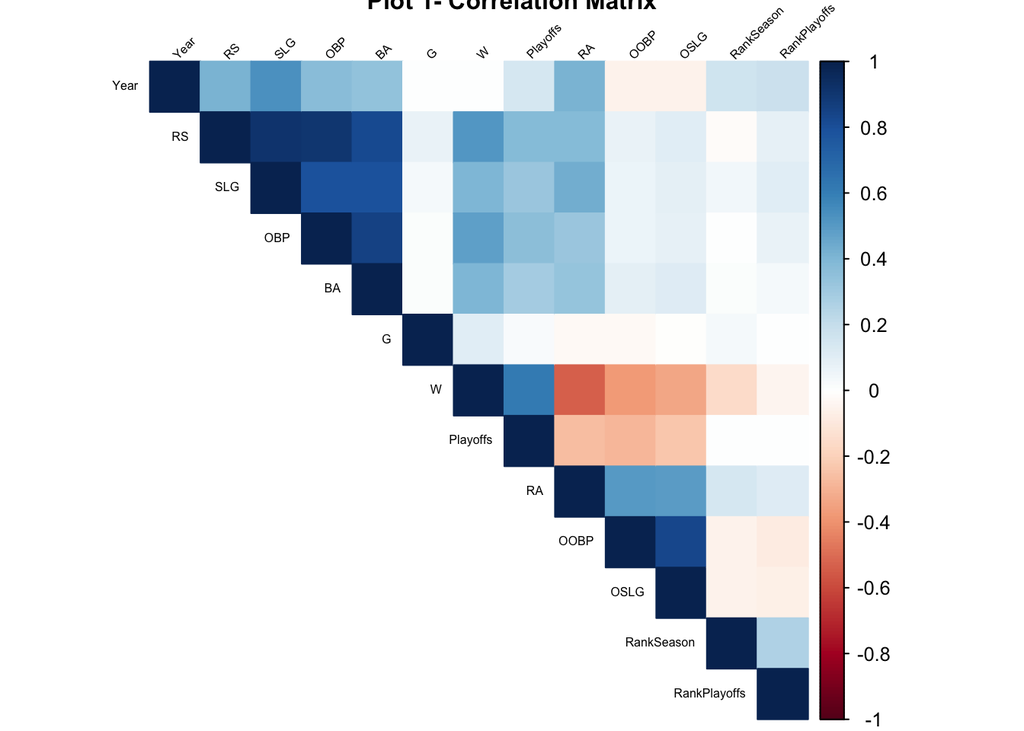

```r
corrplot(correlation_table,
         method = "color",
         type = "upper",
         order = "hclust",
         tl.col = "black",
         tl.srt = 45,
         tl.cex = 0.5,
         addrect = 3,
         title= "Plot 1- Correlation Matrix", cex.main=1)
```

**Interpretation of Plot 1 -**

The above correlation heatmap illustrates the correlation between different variables of baseball dataset. Below is a brief understaniding of the heatmap:

- **Dark Blue**: Indicates a strong positive correlation, meaning as one variable increases, the other tends to increase as well.
- **Dark Red**: Indicates a strong negative correlation, meaning as one variable increases, the other tends to decrease.
- **Light Colors**: Indicate weaker correlations, with lighter blues for weaker positive correlations and lighter reds for weaker negative correlations.
- **White**: Indicates no correlation, meaning there’s no linear relationship between those two variables.

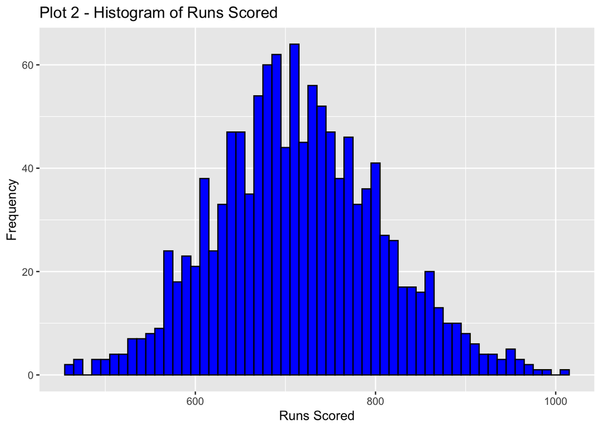

```r
# Histogram for Runs Scored (RS)
ggplot(data = baseball, aes(x = RS)) +
  geom_histogram(binwidth = 10, fill = "blue", color = "black") +
  labs(title = "Plot 2 - Histogram of Runs Scored", x = "Runs Scored", y = "Frequency")
```

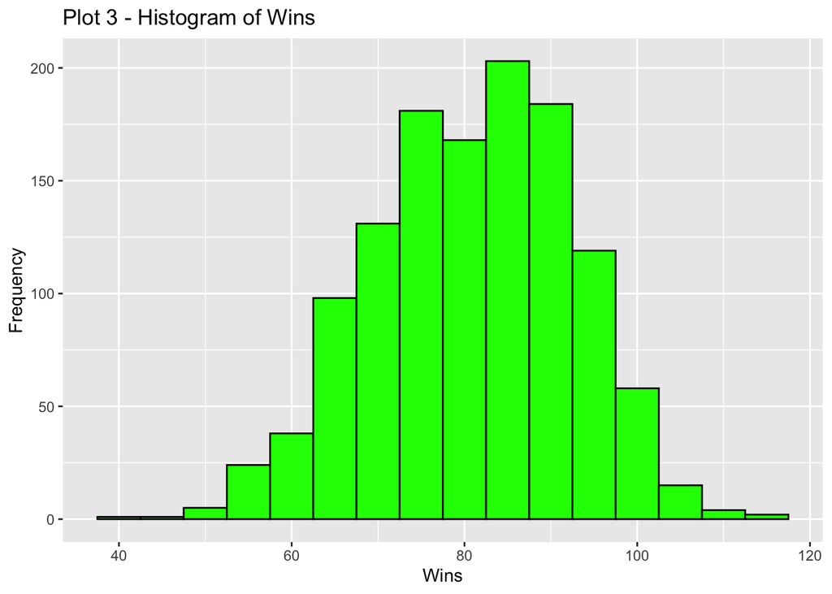

```r
# Histogram for Wins (W)
ggplot(data = baseball, aes(x = W)) +
  geom_histogram(binwidth = 5, fill = "green", color = "black") +
  labs(title = "Plot 3 - Histogram of Wins", x = "Wins", y = "Frequency")
```

I**nterpretation of Plot 3 - Histogram of Wins:**

- In this histogram, the x-axis represents the number of wins, and the y-axis represents the frequency of teams that fall into each range of wins. The bars show the number of teams that have won a certain number of games within specific intervals.
- The distribution seems to be roughly symmetric and bell-shaped, implying a normal-like distribution of wins among the teams.
- Teams with significantly fewer than 70 or more than 90 wins are less frequent, as shown by the shorter bars at the two tails of the histogram.

```r
# Assuming the baseball dataset is loaded in a dataframe called baseball
mean_RS <- mean(baseball$RS, na.rm = TRUE)
median_RA <- median(baseball$RA, na.rm = TRUE)

# Output the results
print(paste("Mean Runs Scored (RS):", mean_RS))
```

```
## [1] "Mean Runs Scored (RS): 715.081980519481"
```

```r
print(paste("Median Runs Allowed (RA):", median_RA))
```

```
## [1] "Median Runs Allowed (RA): 709"
```

The mean RS could provide insight into the average offensive power of teams, while the median RA could give a sense of what a typical team’s defensive performance might be.

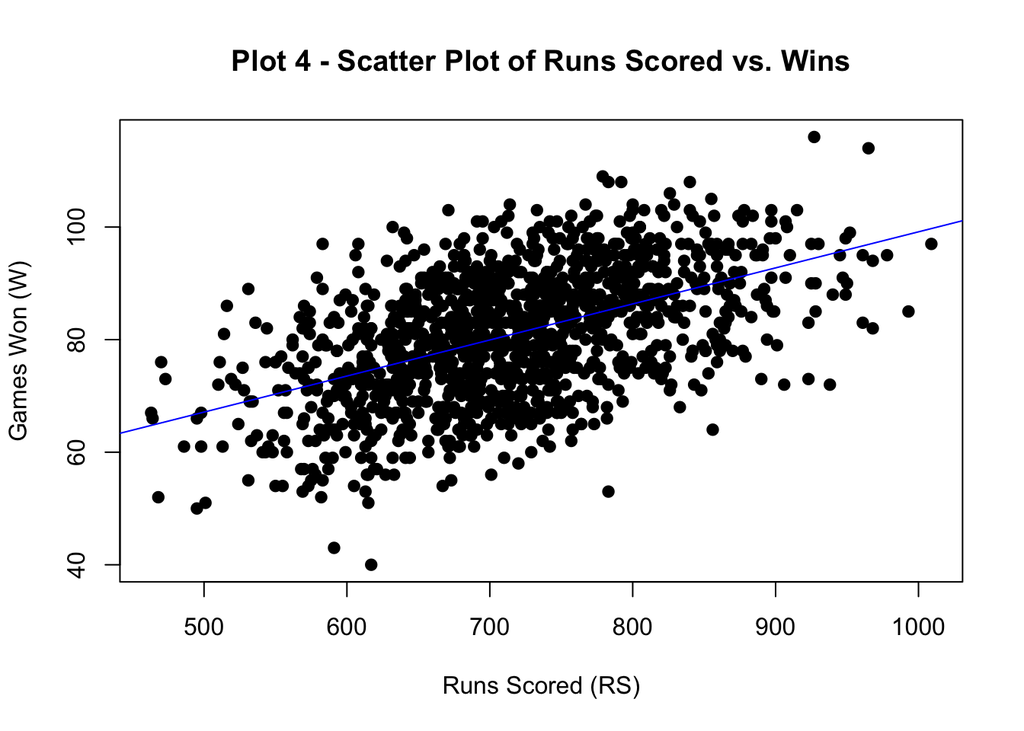

```r
# Calculate the correlation between Runs Scored and Wins
correlation_rs_w <- cor(baseball$RS, baseball$W, use = "complete.obs")

# Create a scatter plot to visualize the relationship
plot(baseball$RS, baseball$W, main = "Plot 4 - Scatter Plot of Runs Scored vs. Wins",
     xlab = "Runs Scored (RS)", ylab = "Games Won (W)", pch = 19)

# Add a regression line to the scatter plot
abline(lm(W ~ RS, data = baseball), col = "blue") #-(OpenAI,2024)
```

```r
# Output the correlation coefficient
print(paste("Correlation coefficient between Runs Scored and Wins:", correlation_rs_w))
```

```
## [1] "Correlation coefficient between Runs Scored and Wins: 0.51174472327652"
```

**Interpretation of Plot 4 -**

- The scatter plot depicts the relationship between Runs Scored (RS) and Games Won (W) in a baseball game.
- Each point on the plot represents a team, with its position determined by how many runs they scored in the season and how many games they won.
- There is a visible upward trend indicated by the points, suggesting a positive relationship between these two variables: as the number of runs scored increases, so generally does the number of games won.
- The linear regression line further highlights this positive correlation, showing the best fit for the data points.